# explore

Exploratory Data Project Analyzing a dataset from the interent using as many Python skills as possbile

Importing the neccessary libraries and csv dataset as well as calling for the first 5 rows to make sure everything has worked

```python
import pandas as pd
import matplotlib as plt
import seaborn as sns

usda_url = "https://www.ers.usda.gov/webdocs/DataFiles/92574/FoodDollarDataNominal.csv?v=5198"

df = pd.read_csv(usda_url)

df.head()
```

|  | table_num | TABLE_NAME | category_num | CATEGORY_DESC | year | Units | salary_and_benefits | output_taxes | property_income | imports | total |
| --- | --- | --- | --- | --- | --- | --- | --- | --- | --- | --- | --- |
| 0 | 1 | Food dollar | 1 | Total | 1993 | Cents per Domestic Food Dollar | 0.0 | 0.0 | 0.0 | 3.9 | 100.0 |
| 1 | 1 | Food dollar | 1 | Total | 1994 | Cents per Domestic Food Dollar | 0.0 | 0.0 | 0.0 | 3.9 | 100.0 |
| 2 | 1 | Food dollar | 1 | Total | 1995 | Cents per Domestic Food Dollar | 0.0 | 0.0 | 0.0 | 4.2 | 100.0 |
| 3 | 1 | Food dollar | 1 | Total | 1996 | Cents per Domestic Food Dollar | 0.0 | 0.0 | 0.0 | 4.3 | 100.0 |
| 4 | 1 | Food dollar | 1 | Total | 1997 | Cents per Domestic Food Dollar | 51.4 | 8.7 | 35.5 | 4.4 | 100.0 |

Calling the info function to see what the csv contains

```python
df.info()
```

```
<class 'pandas.core.frame.DataFrame'>
RangeIndex: 7616 entries, 0 to 7615
Data columns (total 11 columns):
 #   Column               Non-Null Count  Dtype
---  ------               --------------  -----
 0   table_num            7616 non-null   int64
 1   TABLE_NAME           7616 non-null   object
 2   category_num         7616 non-null   int64
 3   CATEGORY_DESC        7616 non-null   object
 4   year                 7616 non-null   int64
 5   Units                7616 non-null   object
 6   salary_and_benefits  7616 non-null   float64
 7   output_taxes         7616 non-null   float64
 8   property_income      7616 non-null   float64
 9   imports              7616 non-null   float64
 10  total                7616 non-null   float64
dtypes: float64(5), int64(3), object(3)
memory usage: 654.6+ KB
```

Calling the len function as a different way to see the number of entries (rows) in the dataset

```python
import numpy as np

len(df)
```

```
7616
```

Max function showing the maximum values of each column

```python
df.max()
```

```
table_num                                                          22
TABLE_NAME             Home food and beverage: Nonalcoholic beverages
category_num                                                       16
CATEGORY_DESC                                         Wholesale trade
year                                                             2021
Units                                                 million dollars
salary_and_benefits                                         898732.96
output_taxes                                                157952.73
property_income                                             708603.04
imports                                                      95726.24
total                                                      2159202.59
dtype: object
```

Min function showing the minimum values in each column

```python
df.min()
```

```
table_num                                           1
TABLE_NAME              Away food and beverage dollar
category_num                                        1
CATEGORY_DESC                             Advertising
year                                             1993
Units                  Cents per Domestic Food Dollar
salary_and_benefits                               0.0
output_taxes                                -21049.12
property_income                                   0.0
imports                                      -5852.93
total                                             0.0
dtype: object
```

Calling the unique function to see the values that appear in the TABLE_NAME column

```python
df.TABLE_NAME.unique()
```

```
array(['Food dollar', 'Food at home dollar', 'Food away from home dollar',
       'Food and beverage dollar', 'Home food and beverage dollar',
       'Away food and beverage dollar', 'Food at home: Cereals',
       'Food at home: Bakery products',
       'Food at home: Beef, pork and other meats',
       'Food at home: Poultry', 'Food at home: Fish and seafood',
       'Food at home: Fresh milk',
       'Food at home: Processed dairy products', 'Food at home: Eggs',
       'Food at home: Fats and oils', 'Food at home: Fresh Fruits',
       'Food at home:  Fresh vegetables',
       'Food at home: Processed fruits and vegetables',
       'Food at home: Sugar and sweets', 'Food at home: Other foods',
       'Home food and beverage: Nonalcoholic beverages',
       'Home food and beverage: Alcoholic beverages'], dtype=object)
```

Creating new DataFrames that show only rows where TABLE_NAME == 'Food at home: Eggs' or 'Food at home: Poultry'

```python
eggs = df[df.TABLE_NAME == 'Food at home: Eggs']
poultry = df[df.TABLE_NAME == 'Food at home: Poultry']

eggs.head()
```

|  | table_num | TABLE_NAME | category_num | CATEGORY_DESC | year | Units | salary_and_benefits | output_taxes | property_income | imports | total |
| --- | --- | --- | --- | --- | --- | --- | --- | --- | --- | --- | --- |
| 3232 | 14 | Food at home: Eggs | 1 | Total | 1997 | Cents per Domestic Food Dollar | 41.1 | 8.6 | 44.4 | 5.9 | 100.0 |
| 3233 | 14 | Food at home: Eggs | 1 | Total | 2002 | Cents per Domestic Food Dollar | 46.6 | 5.9 | 40.9 | 6.6 | 100.0 |
| 3234 | 14 | Food at home: Eggs | 1 | Total | 2007 | Cents per Domestic Food Dollar | 43.7 | 7.5 | 40.9 | 7.9 | 100.0 |
| 3235 | 14 | Food at home: Eggs | 1 | Total | 2012 | Cents per Domestic Food Dollar | 43.3 | 9.4 | 38.3 | 9.0 | 100.0 |
| 3236 | 14 | Food at home: Eggs | 2 | Agribusiness | 1997 | Cents per Domestic Food Dollar | 2.4 | 0.6 | 3.1 | 0.9 | 6.9 |

Using matplotlib to create a scatter plot from the eggs dataframe showing the salary and benefits portion of income vs the recorded year. This graph shows that on average the return value has gone up over time

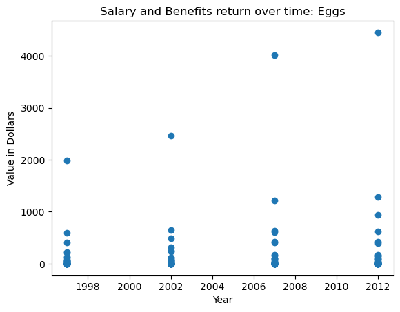

```python
from matplotlib import pyplot as plt

%matplotlib inline

plt.scatter(eggs.year, eggs.salary_and_benefits)
plt.title('Salary and Benefits return over time: Eggs')
plt.xlabel('Year')
plt.ylabel('Value in Dollars')
```

A similar chart for Poultry

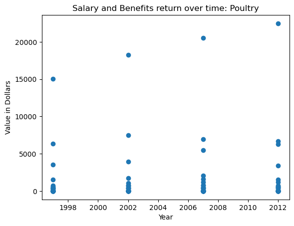

```python
plt.scatter(poultry.year, poultry.salary_and_benefits)
plt.title('Salary and Benefits return over time: Poultry')
plt.xlabel('Year')
plt.ylabel('Value in Dollars')
```